# Simulation Study

Priscilla Oduro

22 November 2019"

This simulation study will help you understand why you should never use the same dataset to fit and evaluate your model. Furthermore, I will compare performance of validation set and cross-validation approaches.

## 1. Generate sample data

Write function that generates the sample data.

```r
set.seed(90)
#generate random variables
x <- sort(rnorm(200, mean = 0, sd = 1))
u <- rnorm(200, mean = 0, sd = 1)

gen_samples<-function(x,u){
  #simulate data
  y <- (1 + x^3 + u)

  #save data as dataframe and set column names:
  data <- as.data.frame(cbind(x,y))
  colnames(data) <-c("x","y")

  return(data)
}

#generate data:
data <- gen_samples(x,u)
```

## 2. Split data in training and validation data.

```r
#Draw row numbers randomly:
set.seed(90)
trainRow = sample(1:nrow(data),0.8*nrow(data))

#Set training- and validation data
train = data[c(trainRow), ]
validation <- data[-c(trainRow),]
```

## 3. Plot

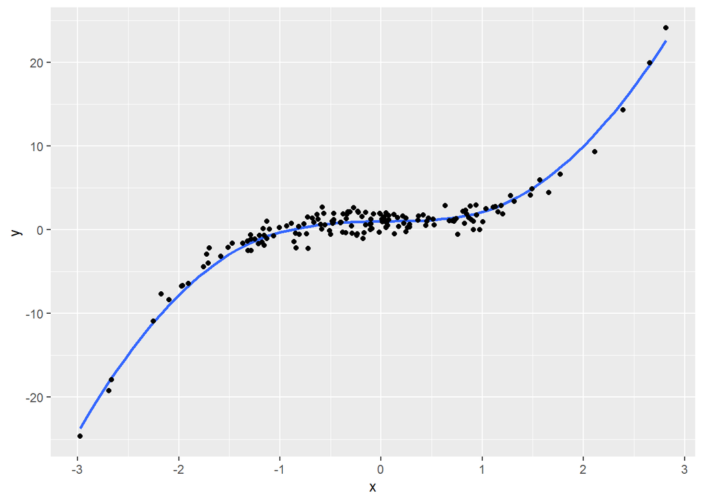

```r
ggplot(data, aes(x, y)) + geom_smooth(method = 'loess',se=FALSE) + geom_point(data = train, aes(x,y))
```

## 4. Code help-functions.

Now let’s code two help-functions. One will compute the MSE of two variables and the other one will compute test error by using cross-validation approach.

```r
calc_mse<-function(y_actual,y_predict){
  #compute MSE
  n = length(y_actual)
  MSE = (1/n) * sum((y_actual-y_predict)^2)

  return(MSE)
}
```

```r
#function that will return the test error by using cross-validation
my.kfold<-function(model,data,K){
  MSE = c()
  n = nrow(data)
  percentage = 1/K
  if (K>n){
    print("Data can not be split evenly into K parts")
    CV_error = NA
  }
  else{
    #draw for each K row numbers:
    split_nrows = split(sample(1:n), 1:K)

  for (i in 1:K){
    #divide for each iteration the data in training and validation set:
    train_nrow = as.vector(unlist(split_nrows[-i]))
    train_data = data[train_nrow,]
    validation_data = data[-train_nrow,]

    #fit model for training data:
    lm.fit = update(model, data = train_data)

    #compute mse with validation set:
    MSE[i] = calc_mse(validation_data[,2],predict(lm.fit,data)[-train_nrow])
  }

  CV_error = sum(MSE)/K
  }
  return(CV_error)
}
```

## 5. Simulation study

Compare polynomial fits of orders one to ten by using validation set and cross-validation methods (K=10). Also I will show why you should not use training data set to evaluate the model. I will set the number of replication to 100.

```r
replication = 100
poly_degree = 10
n = 200
#generate a list that will contain training errors, validation errors and cross validation errors for each replication:
error_collection_training = data.frame(matrix(ncol = replication, nrow = poly_degree))
error_collection_val_approach = data.frame(matrix(ncol = replication, nrow = poly_degree))
error_collection_cv = data.frame(matrix(ncol = replication, nrow = poly_degree))
error_collection = list("training"= error_collection_training, "vsa" = error_collection_val_approach, "cv"=error_collection_cv)

#list will contain all the chosen polynomial degree based on training MSEs, validation set approach MSEs and CV errors:
min_error_collection = list("training"=c(), "vs"=c(),"cv"=c())

#Start simulation
set.seed(90)
for (j in 1:replication){
  #simulate data and set training and validation set:
  #generate random variables
  x <- sort(rnorm(200, mean = 0, sd = 1))
  u <- rnorm(200, mean = 0, sd = 1)
  data <- gen_samples(x,u)
  trainRow = sample(1:nrow(data),0.8*nrow(data))
  train = data[c(trainRow), ]
  validation <- data[-c(trainRow),]

  for (k in 1:poly_degree){
    #fit the model:
    model = lm(y ~poly(x, k,raw = TRUE), data = data)
    #fit the model with training data:
    lm.fit = update(model,data = train)

    #MSE of training data for each polynomial degree:
    error_collection[[1]][k,j] = calc_mse(train[,2],predict(lm.fit,data)[trainRow])

    #Validation set approach MSE:
    error_collection[[2]][k,j] = calc_mse(validation[,2],predict(lm.fit, data)[-trainRow])

    #CV error:
    error_collection[[3]][k,j] = my.kfold(model,data,10)
  }
  #choose the polynomial with the lowest MSE or. CV error:
  min_error_collection[[1]][j] = which.min(error_collection[[1]][,j])
  min_error_collection[[2]][j] = which.min(error_collection[[2]][,j])
  min_error_collection[[3]][j] = which.min(error_collection[[3]][,j])
}
```

Creating a table for the results. The rows will contain the polynomial order and the columns the mean and standard deviation of the training erro, validation error and cross-validation error.

```r
result = matrix(NA,ncol = 6, nrow = poly_degree)
colnames(result) = c( "Mean ,Train ","SD, Train "," Mean, VS "," SD, VS ", "Mean, CV ", "SD, CV")
row.names(result) = 1:poly_degree

for (l in 1:poly_degree) {
  result[l,1] = sum(error_collection[[1]][l,])/replication
  result[l,2] = sd(error_collection[[1]][l,])
  result[l,3] = sum(error_collection[[2]][l,])/replication
  result[l,4] = sd(error_collection[[2]][l,])
  result[l,5] = sum(error_collection[[3]][l,])/replication
  result[l,6] = sd(error_collection[[3]][l,])
}
result
```

```
##    Mean ,Train  SD, Train   Mean, VS    SD, VS  Mean, CV     SD, CV
## 1         6.376      3.340       9.05    14.588      7.36     4.422
## 2         5.737      2.614       8.90    12.028      7.92     4.454
## 3         0.982      0.111       1.01     0.208      1.03     0.107
## 4         0.976      0.110       1.03     0.227      1.08     0.193
## 5         0.968      0.108       1.21     1.246      1.17     0.291
## 6         0.961      0.105       7.86    61.120      2.01     5.934
## 7         0.954      0.106      31.04   188.146      9.94    48.937
## 8         0.949      0.107      87.57   704.797     46.25   303.324
## 9         0.943      0.107     856.31  4987.979    341.44  1716.928
## 10        0.936      0.104    2231.40 13227.829   4241.26 31299.721
```

Taking a look at the table, we can see that the mean training error monotonically decreases where as the test error (VS error and 10-fold CV error) increases after reaching the polynomial degree of 3 (the true function).

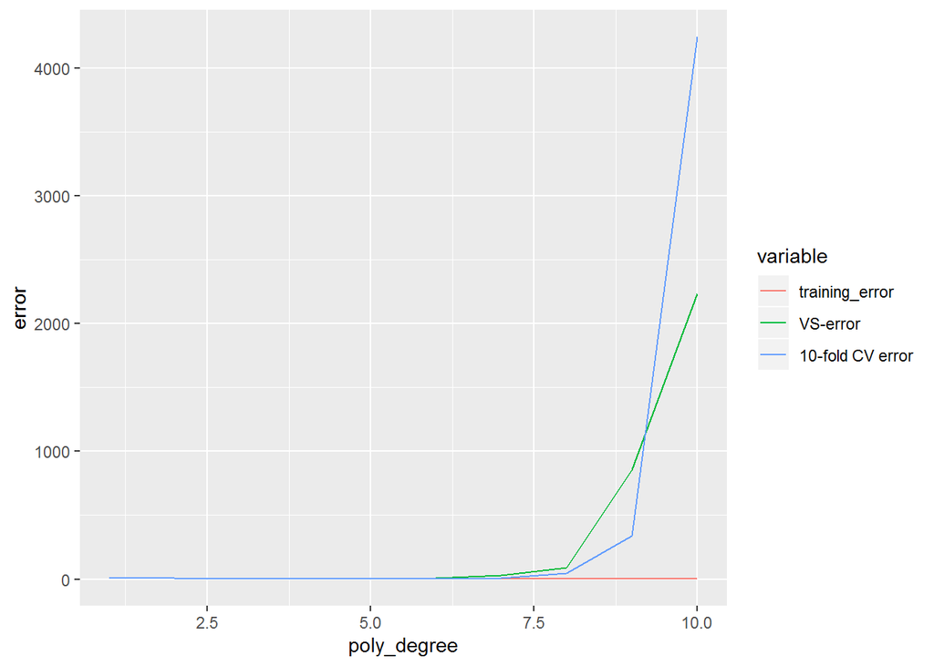

```r
plot_data = as.data.frame(cbind(result[,1],result[,3], result[,5]))
colnames(plot_data) <- c("training_error","VS-error","10-fold CV error")
plot_data['poly_degree'] <- 1:10

#reshape data for plotting
plot_data = reshape2::melt(plot_data, id.var='poly_degree')
names(plot_data)[3] <- 'error'
#plot
ggplot(plot_data, aes(x=poly_degree, y=error, col=variable)) + geom_line()
```

Now let’s check how many times (out of 100) training error, validation set error and CV error choose polynomial degrees from 1 to 10 based on training.

```r
library(gridExtra)
```

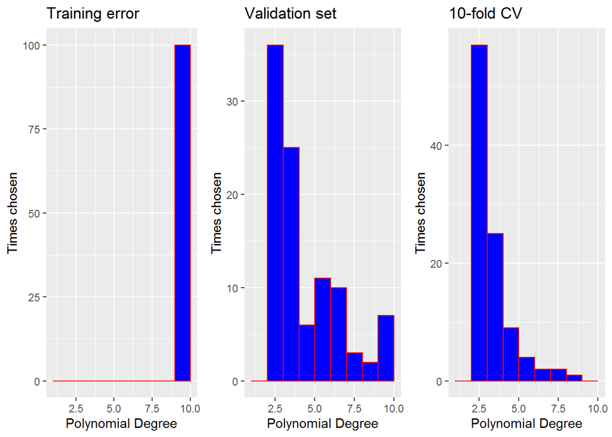

```r
min_error_collection = as.data.frame(min_error_collection)
par(mfrow=c(1,3))
p1 = ggplot(min_error_collection, aes(x=training)) + geom_histogram(breaks=seq(1, 10, by=1),fill=I("blue"), col=I("red")) + labs(title= "Training error",y="Times chosen", x = "Polynomial Degree")

p2 = ggplot(min_error_collection, aes(x=vs)) + geom_histogram(breaks=seq(1, 10, by=1),fill=I("blue"), col =I("red")) + labs(title= "Validation set",y="Times chosen", x = "Polynomial Degree")

p3 = ggplot(min_error_collection, aes(x=cv)) + geom_histogram(breaks=seq(1, 10, by=1),fill=I("blue"), col=I("red")) + labs(title= "10-fold CV",y="Times chosen", x = "Polynomial Degree")

grid.arrange(p1, p2, p3, nrow = 1)
```

```r
fraction_vsa = sum(min_error_collection[[2]]==3)*100/replication
fraction_cv = sum(min_error_collection[[3]]==3)*100/replication

cat("We know our model has polynomial degree 3. So we can obviously see in the histogram that using the training data for testing, is not a good idea. For the validation set approach we have a ",fraction_vsa,"% chance to choose the right model. On the other hand, for cross-validation there is a",fraction_cv," % chance. Hence 10-fold cross-validation is a better choice")
```

[output not shown]